# w3_assessment

In this assignment we'll ask you to plot multiple variables.

You will use what you find in this assignment to answer the questions in the quiz that follows. It may be useful to keep this notebook side-by-side with this week's quiz on your screen.

```python
import numpy as np
import pandas as pd
import seaborn as sns
import scipy.stats as stats
import matplotlib.pyplot as plt
pd.set_option('display.max_columns', 100)

path = "Cartwheeldata.csv"
```

```python
# First, you must import the cartwheel data from the path given above
#Primeiro, você deve importar os dados da estrela do caminho fornecido acima
df = pd.read_csv("Cartwheeldata.csv")# using pandas, read in the csv data found at the url defined by 'path'
```

```python
# Next, look at the 'head' of our DataFrame 'df'.
df.count()
```

```
ID               25
Age              25
Gender           25
GenderGroup      25
Glasses          25
GlassesGroup     25
Height           25
Wingspan         25
CWDistance       25
Complete         25
CompleteGroup    25
Score            25
dtype: int64
```

```python
df.head(5)
```

|  | ID | Age | Gender | GenderGroup | Glasses | GlassesGroup | Height | Wingspan | CWDistance | Complete | CompleteGroup | Score |
| --- | --- | --- | --- | --- | --- | --- | --- | --- | --- | --- | --- | --- |
| 0 | 1 | 56 | F | 1 | Y | 1 | 62.0 | 61.0 | 79 | Y | 1 | 7 |
| 1 | 2 | 26 | F | 1 | Y | 1 | 62.0 | 60.0 | 70 | Y | 1 | 8 |
| 2 | 3 | 33 | F | 1 | Y | 1 | 66.0 | 64.0 | 85 | Y | 1 | 7 |
| 3 | 4 | 39 | F | 1 | N | 0 | 64.0 | 63.0 | 87 | Y | 1 | 10 |
| 4 | 5 | 27 | M | 2 | N | 0 | 73.0 | 75.0 | 72 | N | 0 | 4 |

If you can't remember a function, open a previous notebook or video as a reference, or use your favorite search engine to look for a solution.

## Scatter plots

First, let's looks at two variables that we expect to have a strong relationship, 'Height' and 'Wingspan'.

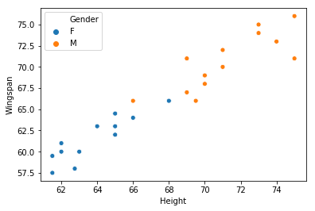

```python
# Make a Seaborn scatter plot with x = height and y = wingspan using sns.scatterplot(x, y)
sns.scatterplot(data = df, x = 'Height', y = 'Wingspan', hue="Gender")
```

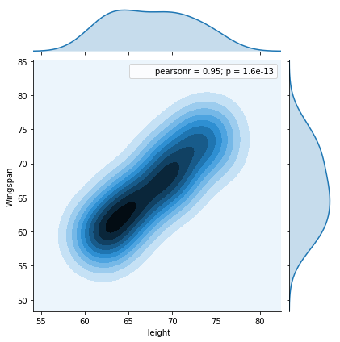

```python
sns.jointplot(x="Height", y="Wingspan", kind='kde', data=df).annotate(stats.pearsonr)
```

How would you describe the relationship between 'Height' and 'Wingspan'?  
Questions you can ask:

- Is it linear?
- Are there outliers?
- Are their ranges similar or different?

How else could you describe the relationship?

The relationship between the two variables appear to be quite linear but the two groups of males and females have significantly different ranges of value (with males with generally greater overall values). Also. males appear to have few poossible outliers at high values

How would you describe the relationship between 'Height' and 'Wingspan'? Questions you can ask:

Now let's look at two variables that we don't yet assume have a strong relationship, 'Wingspan' and 'CWDistance' Agora, vamos olhar para duas variáveis que ainda não assumimos ter um relacionamento forte, 'Wingspan' e 'CWDistance'

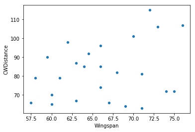

```python
# Make a Seaborn scatter plot with x = wingspan and y = cartwheel distance
sns.scatterplot(data = df, x = 'Wingspan', y = 'CWDistance')
```

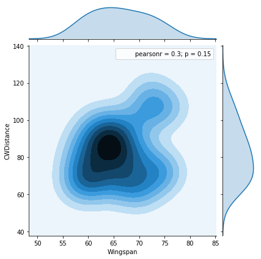

```python
sns.jointplot(x="Wingspan", y="CWDistance", kind='kde', data=df).annotate(stats.pearsonr)
```

How would you describe the relationship between 'Wingspan' and 'CWDistance'?

- Is it linear?
- Are there outliers?
- Are their ranges similar or different?

How else could you describe the relationship? The two variables appear to have almost no correlation. Moreover males and females appear to belong to almost separated groups of values: males are characterized by generally greater Wingspan values

How would you describe the relationship between 'Wingspan' and 'CWDistance'?

Is it linear? Are there outliers? Are your intervals similar or different? How else could you describe the relationship? The two variables appear to have almost no correlation. Furthermore, men and women seem to belong to almost separate value groups: men are characterized by generally higher Wingspan values

Let makes the same plot as above, but now include 'Gender' as the color scheme by including the argument

```
hue=df['Gender']
```

in the Seaborn function

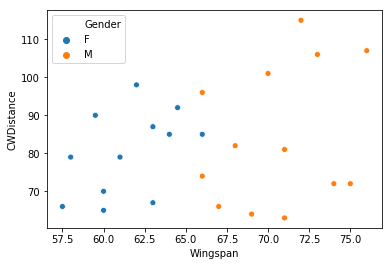

```python
# Make a Seaborn scatter plot with x = wingspan and y = cartwheel distance, and hue = gender
sns.scatterplot('Wingspan', 'CWDistance', data= df, hue=df['Gender'])
```

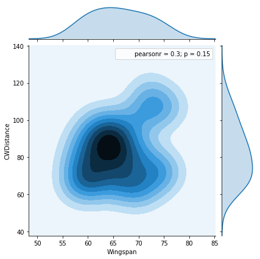

```python
sns.jointplot(x="Wingspan", y="CWDistance", kind='kde', data=df).annotate(stats.pearsonr)
```

```python
df["CWDistance"].describe()
```

```
count     25.000000
mean      82.480000
std       15.058552
min       63.000000
25%       70.000000
50%       81.000000
75%       92.000000
max      115.000000
Name: CWDistance, dtype: float64
```

```python
IQCW=92-70
print(IQCW)
```

```
22
```

```python
df["Wingspan"].describe()
```

```
count    25.000000
mean     66.260000
std       5.492647
min      57.500000
25%      62.000000
50%      66.000000
75%      71.000000
max      76.000000
Name: Wingspan, dtype: float64
```

```python
71-62
```

```
9
```

Does does this new information on the plot change your interpretation of the relationship between 'Wingspan' and 'CWDistance'? Yes, see above

## Barcharts

Now lets plot barplots of 'Glasses'

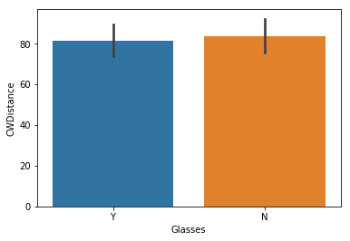

```python
# Make a Seaborn barplot with x = glasses and y = cartwheel distance
sns.barplot(x="Glasses", y="CWDistance", data=df)
```

What can you say about the relationship of 'Glasses' and 'CWDistance'?

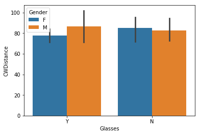

```python
# Make the same Seaborn boxplot as above, but include gender for the hue argument
sns.barplot(x="Glasses", y="CWDistance", hue="Gender", data=df)
```

How does this new plot change your interpretation about the relationship of 'Glasses' and 'CWDistance'?

```python
stats.iqr(df.CWDistance)
```

```
22.0
```

```python
stats.iqr(df.CWDistance[df.Gender=="F"])
```

```
18.5
```

```python
stats.iqr(df.CWDistance[df.Gender=="M"])
```

```
29.0
```

```python
stats.iqr(df.Wingspan)
```

```
9.0
```

```python
df.head()
```

|  | ID | Age | Gender | GenderGroup | Glasses | GlassesGroup | Height | Wingspan | CWDistance | Complete | CompleteGroup | Score |
| --- | --- | --- | --- | --- | --- | --- | --- | --- | --- | --- | --- | --- |
| 0 | 1 | 56 | F | 1 | Y | 1 | 62.0 | 61.0 | 79 | Y | 1 | 7 |
| 1 | 2 | 26 | F | 1 | Y | 1 | 62.0 | 60.0 | 70 | Y | 1 | 8 |
| 2 | 3 | 33 | F | 1 | Y | 1 | 66.0 | 64.0 | 85 | Y | 1 | 7 |
| 3 | 4 | 39 | F | 1 | N | 0 | 64.0 | 63.0 | 87 | Y | 1 | 10 |
| 4 | 5 | 27 | M | 2 | N | 0 | 73.0 | 75.0 | 72 | N | 0 | 4 |

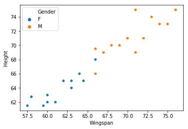

```python
sns.scatterplot('Wingspan', 'Height', data= df, hue=df['Gender'])
```

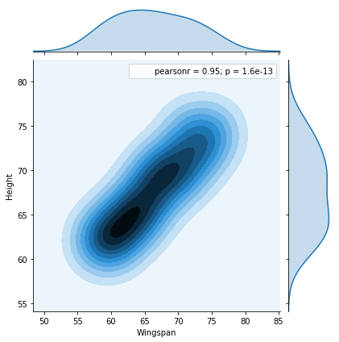

```python
sns.jointplot(x="Wingspan", y="Height", kind='kde', data=df).annotate(stats.pearsonr)
```

```python
df.describe()
```

|  | ID | Age | GenderGroup | GlassesGroup | Height | Wingspan | CWDistance | CompleteGroup | Score |
| --- | --- | --- | --- | --- | --- | --- | --- | --- | --- |
| count | 25.000000 | 25.000000 | 25.000000 | 25.000000 | 25.000000 | 25.000000 | 25.000000 | 25.00000 | 25.000000 |
| mean | 13.000000 | 28.240000 | 1.520000 | 0.560000 | 67.650000 | 66.260000 | 82.480000 | 0.76000 | 6.400000 |
| std | 7.359801 | 6.989754 | 0.509902 | 0.506623 | 4.431187 | 5.492647 | 15.058552 | 0.43589 | 2.533114 |
| min | 1.000000 | 22.000000 | 1.000000 | 0.000000 | 61.500000 | 57.500000 | 63.000000 | 0.00000 | 2.000000 |
| 25% | 7.000000 | 24.000000 | 1.000000 | 0.000000 | 64.000000 | 62.000000 | 70.000000 | 1.00000 | 4.000000 |
| 50% | 13.000000 | 26.000000 | 2.000000 | 1.000000 | 68.000000 | 66.000000 | 81.000000 | 1.00000 | 6.000000 |
| 75% | 19.000000 | 29.000000 | 2.000000 | 1.000000 | 71.000000 | 71.000000 | 92.000000 | 1.00000 | 8.000000 |
| max | 25.000000 | 56.000000 | 2.000000 | 1.000000 | 75.000000 | 76.000000 | 115.000000 | 1.00000 | 10.000000 |

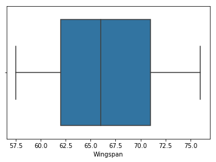

```python
sns.boxplot(df["Wingspan"])
```

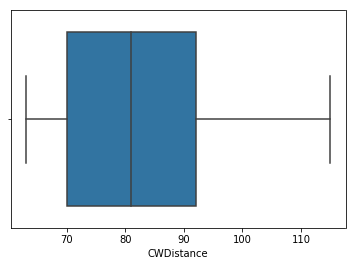

```python
sns.boxplot(df["CWDistance"])
```